# Matchup effects in Australian Football

Possession chain modelling and defensive assignment

Rex Carruthers

## Motivation

- Matchups are central to AFL tactics, but does a tag work, and how?
- Champion Data has developed an algorithm to assign matchups automatically using tracking data

**Possession chain:** An unbroken sequence of play where one team has possession of the ball

- Aim 1 - Estimate attacking and defensive matchup effects using possession chains
- Aim 2 - Classify those matchups
- Aim 3 - Build a tool to optimise them in real game scenarios

[figure not shown]

## Data

Full 2025 AFL season, 216 games

Four linked tables:

- **Metrics** - Player Ratings
- **Possession Chains** - ~53,000
- **Matchups** - Automatically generated
- **Positions** - Manually assigned live and season roles

5 games were removed due to GPS data quality issues impacting the matchup algorithm

1,839,732 observations of possession chain matchups from a player’s perspective

Additionally, each player’s x/y location at the start and end of every chain for a **single round**

## Player Matchups

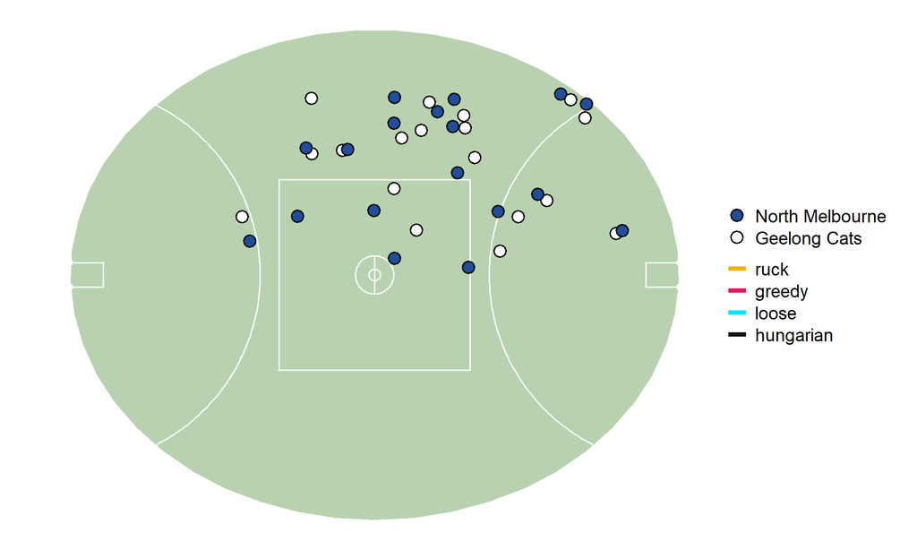

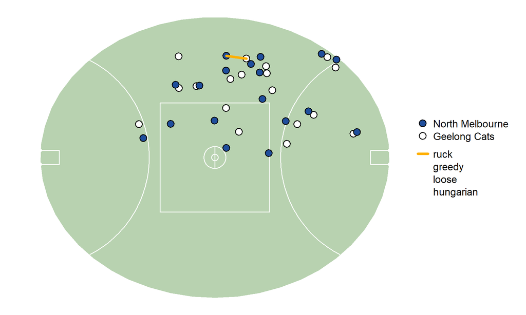

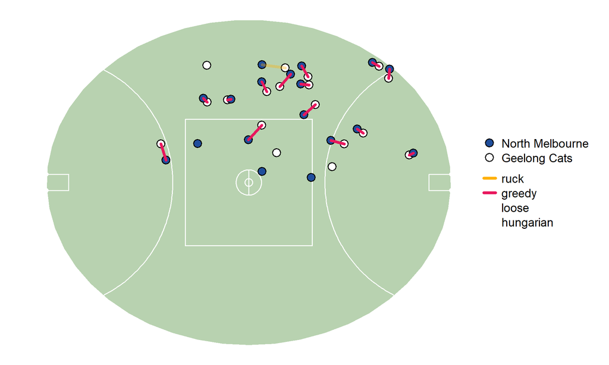

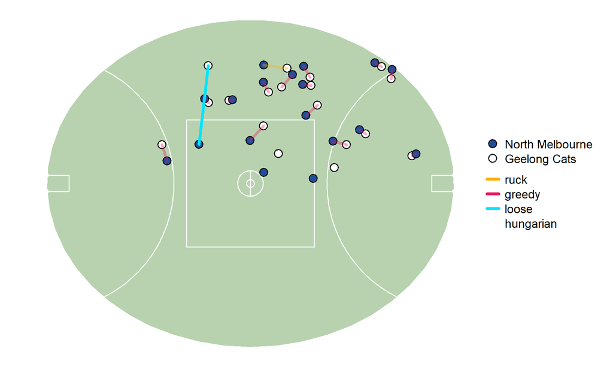

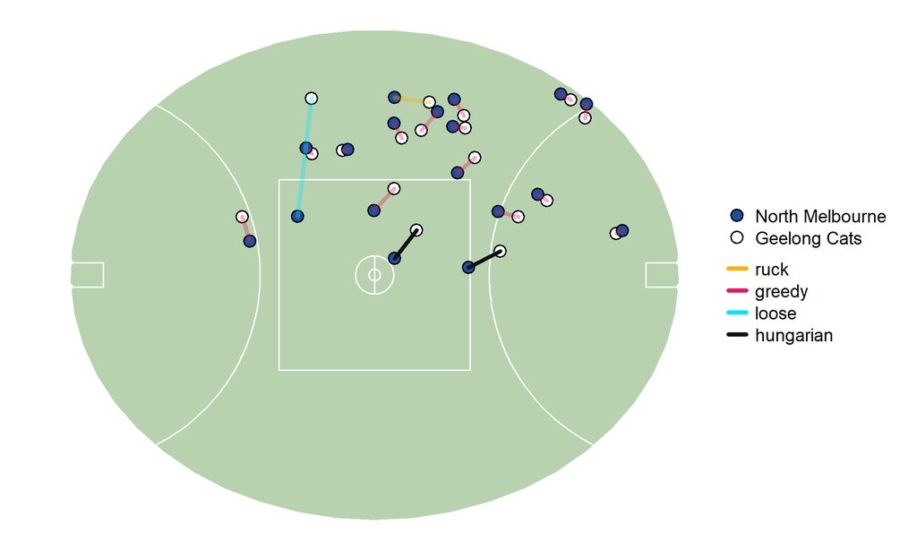

## Player Ratings - Response Variable

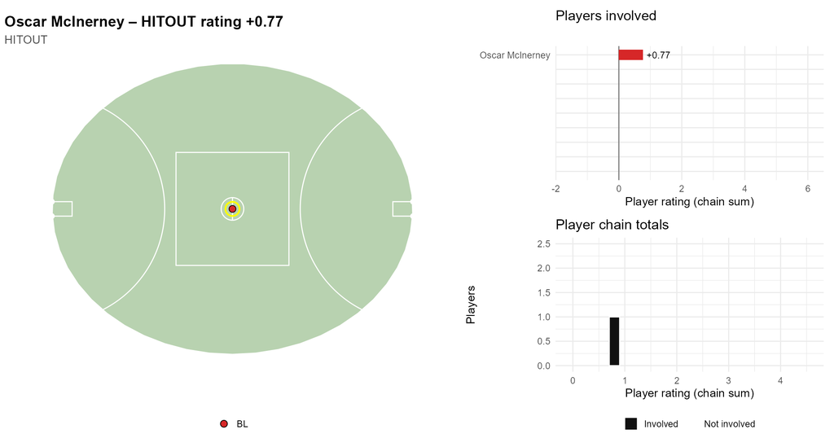

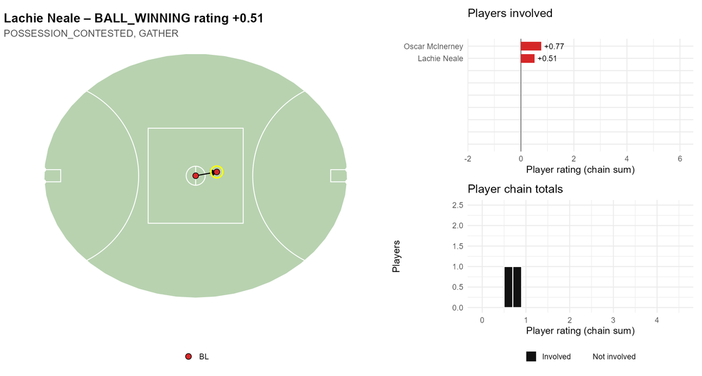

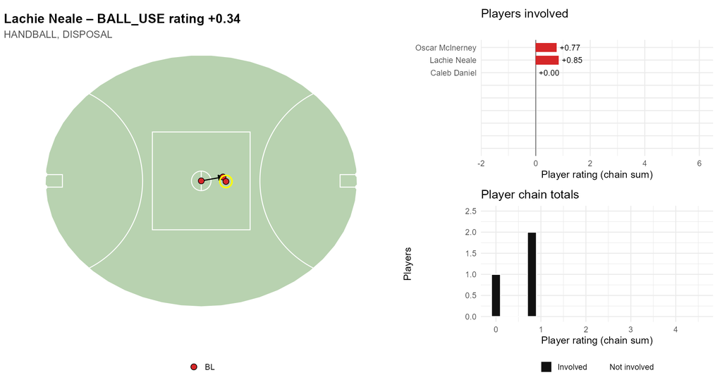

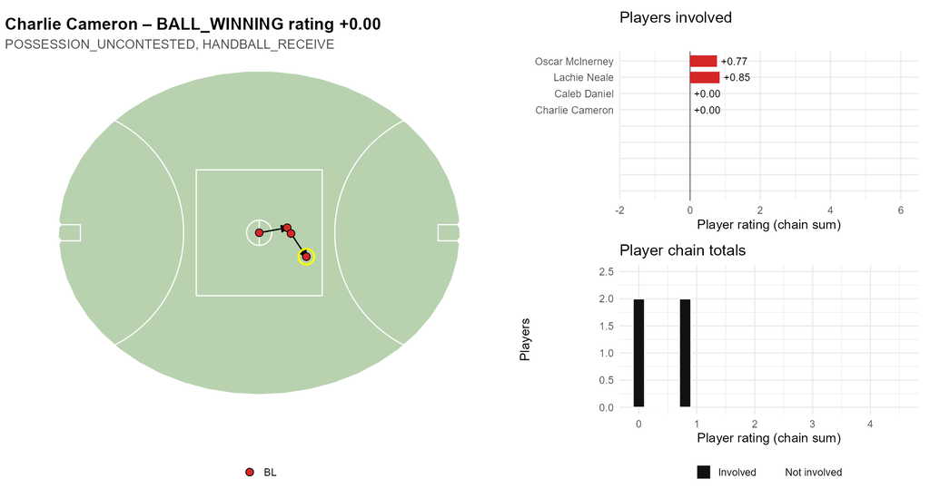

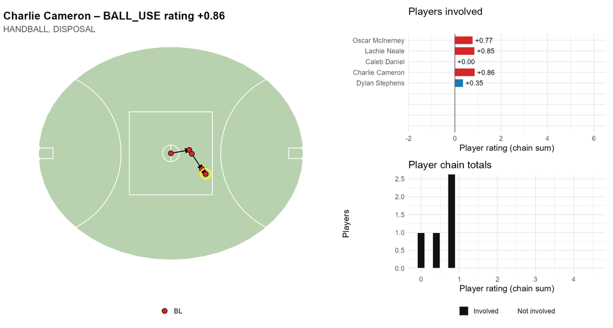

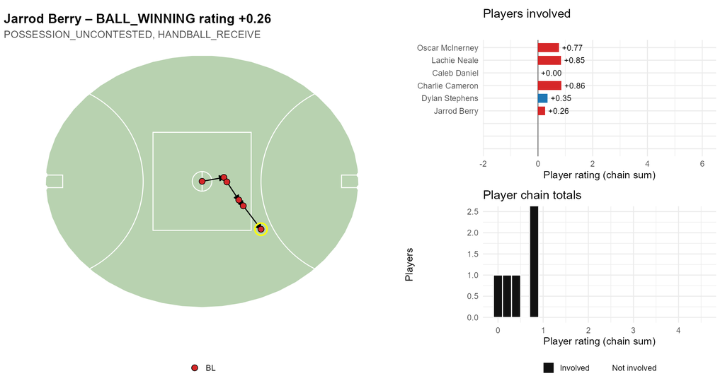

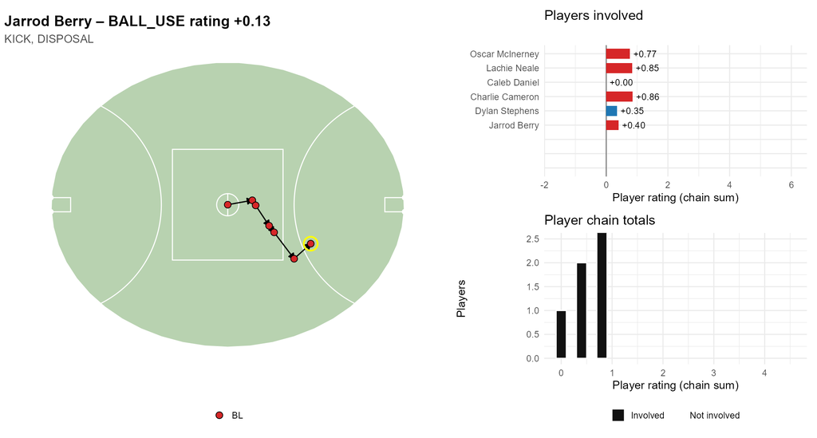

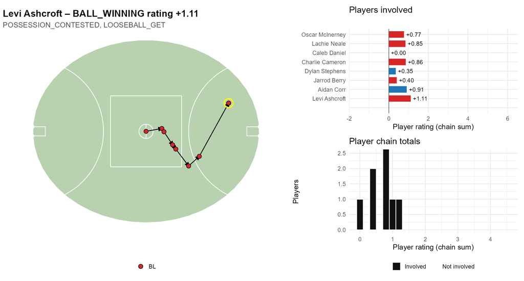

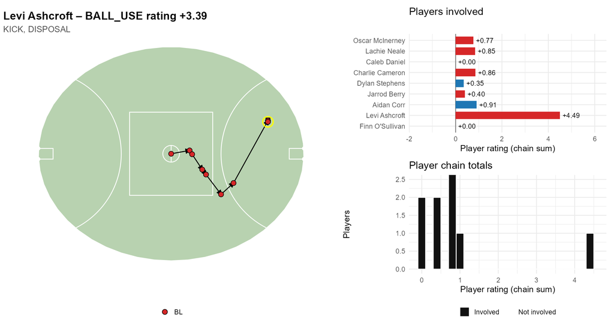

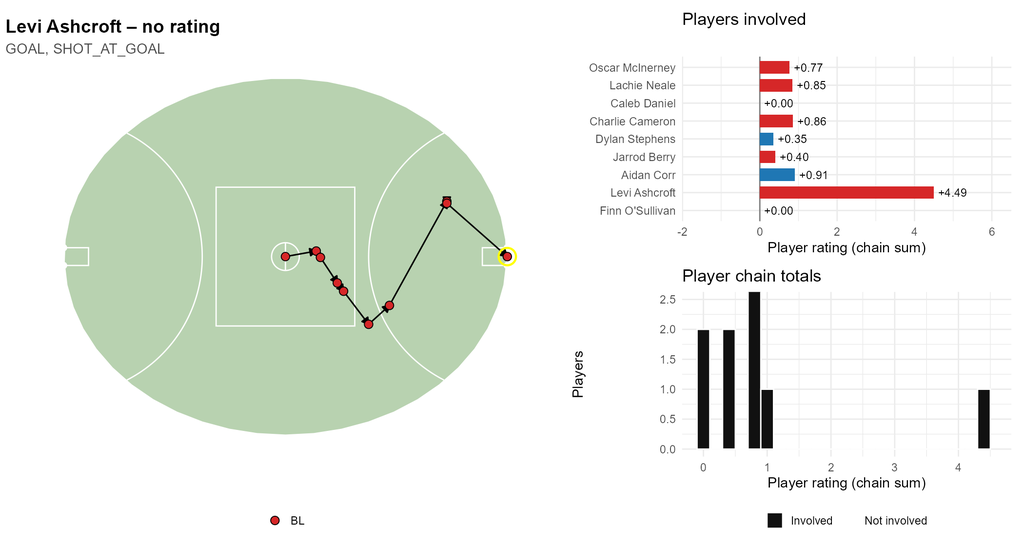

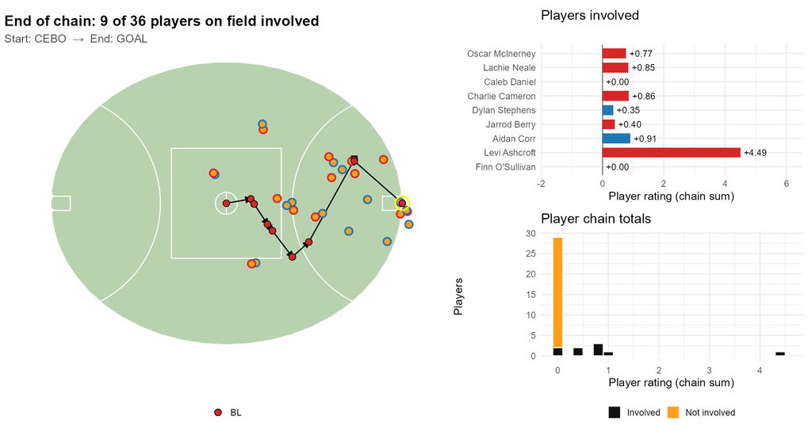

## Extended to the whole game

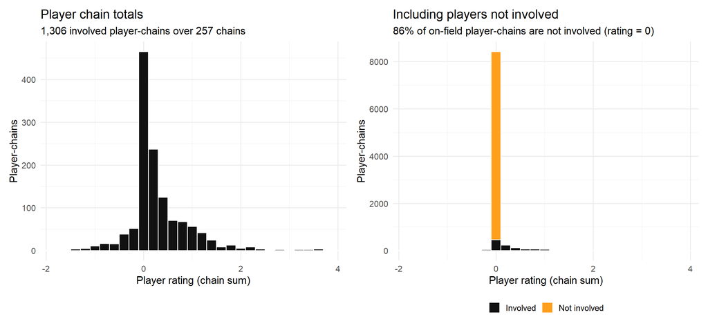

## Hurdle Model

One distribution can’t adequately represent a response variable that is ~87.7% zero and, importantly, can’t separate the two ways a matchup reduces output:

- Limiting how often a player is involved in play
- Reducing the Player Ratings accrued when they are

A two-part hurdle gives each mechanism its own component:

$$y_i \sim
\begin{cases}
0 & \text{with probability } \pi_i \\[4pt]
\text{SkewNormal}(\xi_i, \omega, \alpha) & \text{with probability } 1 - \pi_i
\end{cases}$$

where $\xi_i$ is location, $\omega$ scale, $\alpha$ skewness.

## Model Features

- Player Errol Gulden
- Opponent Loose
- Distance Category 17.5-Inf
- Possession Att
- Chain Start Area B50
- Player Season Role Wing
- Chain Seconds 51.28
- Tag Role Neither
- Distance to Chain Start 24.6

The focal player for the observation

- 668 Players

Their opponent assigned by the Champion Data algorithm

- 669 Players, including Loose

The average distance between the matched pair during the possession chain broken into 10 decile bins

- Loose players are assigned a distance of 20m which is within the largest bin

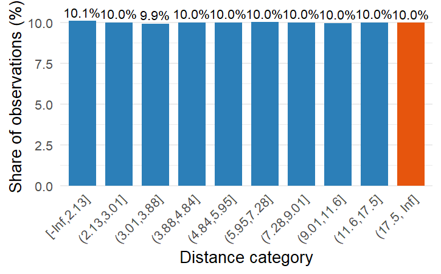

State of possession of the ball for the players team at the start of the chain

- Attack - **31.4%**
- Defence - **29.3%**
- In dispute - **39.3%**

Section of the field the chain started in from the players perspective

- Back 50 - **21.0%**
- Centre - **19.8%**
- Wing - **38.3%**
- Forward 50 - **21.0%**

Current position of the player for the possession chain. Manually assigned live at the game and converted to season level roles

Length of the possession chain in seconds of game time

Tagger, Target or Neither

**Proximity**

- The distance between the matched pair is closer than expectation
- Compared to a GAM predicting distance given the possession chain context

**Persistence**

- Matched up for a minimum of 14 consecutive chains with a maximum gap of 3

**Role Asymmetry**

- The players differ in attacking output or field position
- Identifies the direction of the tag

The player’s distance to where the chain started

- Only available for Round 9

## Final Model

```r
f <- bf(
  ## SKEW NORMAL
  rating ~ possession + dist_cat + tag_role +
    (1 | p | player_player) +
    (0 + is_target_num | opp_player),

  ## HURDLE
  hu ~ chain_start_area * player_seas_role +
    chain_secs + possession + dist_cat +
    tag_role +
    (1 | tag_role:player_seas_role) +
    (1 | p | player_player) +
    (1 + is_target_num | opp_player)
)
```

```r
fit <- brm(
  formula  = f,
  data     = model_data,
  family   = hurdle_skew_normal,
  stanvars = stanvars,
  prior    = pr,
  init     = 0.1,
  control  = list(adapt_delta = 0.9,
                  max_treedepth = 10),
  chains   = 4,
  iter     = 1750,
  warmup   = 750,
  backend  = "cmdstanr",
  seed     = MASTER_SEED
)
```

## Results

## Matchup Distance

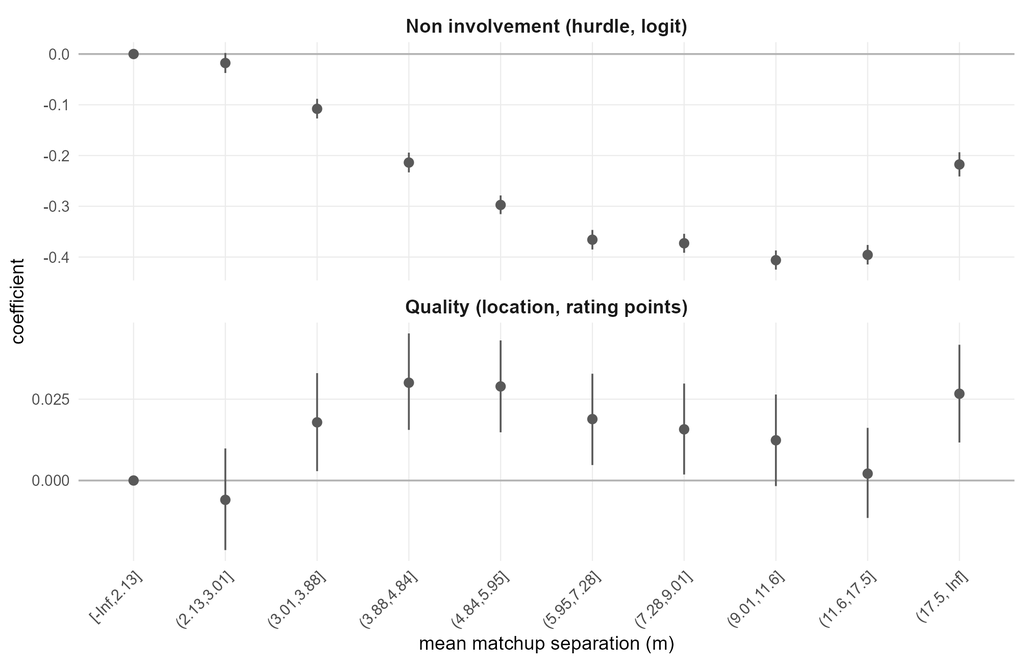

- Decrease in the hurdle logit means more likely to be involved in play
- Quality (non-zero component) is essentially flat

## Tagging

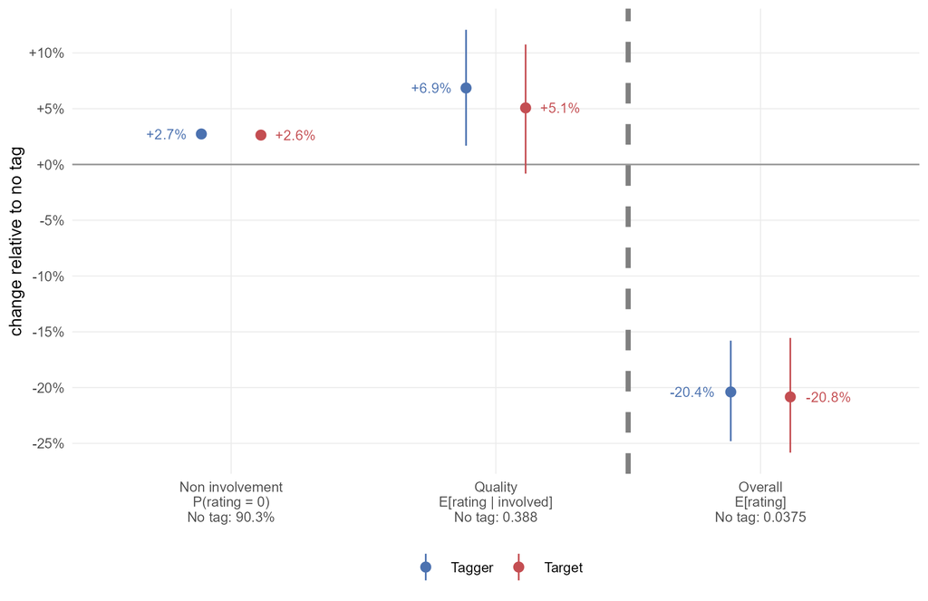

- Tagging and being tagged reduce a player’s expected Player Ratings in a chain by ~20%
- The symmetrical effect means that the power of tagging is in the selection of players

## Player Effects

[interactive chart not shown]

## Involvement Suppression

**Most suppressive**

| Player | Position | Estimate |
| --- | --- | --- |
| Loose | — | 0.490 |
| Jack Payne | Key Def | 0.415 |
| Tom Barrass | Key Def | 0.414 |
| Jeremy Sharp | Wing | 0.371 |
| Ben Miller | Key Def | 0.361 |

**Least suppressive**

| Player | Position | Estimate |
| --- | --- | --- |
| Tom Mitchell | Mid | −0.383 |
| Matt Rowell | Mid | −0.359 |
| Tom Liberatore | Mid | −0.354 |
| Matt Flynn | Ruck | −0.342 |
| Dante Visentini | Ruck | −0.328 |

- Being loose suppresses involvement similarly to being tagged
- Estimates are conditional on matchup proximity

## Application

## Matchup Optimisation Engine

Developed a flexible engine that assigns players to opponents to maximise a chosen objective, under user constraints.

[figure not shown]

## Defensive Assignment

[interactive chart not shown]

## Limitations and Future Direction

## Hurdle Model

- The skew normal distribution provided only an approximate fit for the non-zero values
- Model could be refit with a skew-t or Laplace distribution

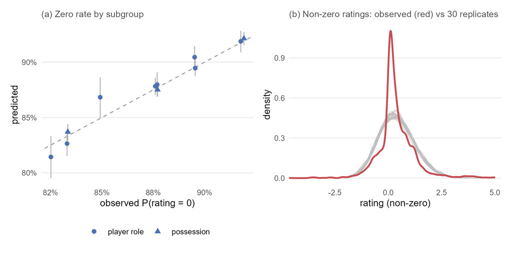

## Tracking Data

- Full season player tracking data
- Replacing the **chain start area × role** interaction term with the player’s **distance to the start of the chain**
- Δelpd = 1013.7 (SE = 51.4) - ~20 standard errors

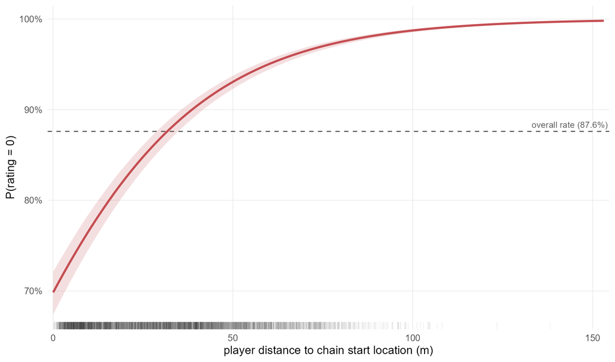

## Applications

Matchup Assignment

- Validation of the matchup recommendations
- Extension to include game theory to account for the other teams objectives
- Simulate games with the assigned optimal matchups rather than utilising past game scenarios

Tagging Definition

- Validation and tuning of the tagging definition with input from industry experts
- Creation of a tool to monitor matchups and tags live throughout a game

## Conclusion

- Matchups primarily affect how often a player is involved, not how well they perform when they are
- Individual attacking and defensive ability can be estimated at the possession-chain level
- Tagging has been given an operational definition and, as defined, has a symmetrical cost
- Loose is the most suppressive opponent level, comparable to being tagged
- The model supports **prospective** decisions, quantifying the attacking and defensive trade-offs they involve

Questions?

[figure not shown]

## Appendix

## Model Fitting

- **Round 9** - Feature selection - Intercept-only → fixed effects → distance parameterisations → player and opponent random effects → tagging terms.
- **Quarter season (n = 500,000)** - convergence diagnostics *worsened*, localised to the opponent correlation block
- **Fix** - separated the block, dropped the location-side opponent intercept. All diagnostics cleared; no population-level estimate moved more than 1 posterior SD
- **Full season** - brms exceeded memory; dense design and random effect matrices
- **Reimplemented in NumPyro/JAX** - verified equivalent on the quarter-season subset before fitting the full data

## Simulation

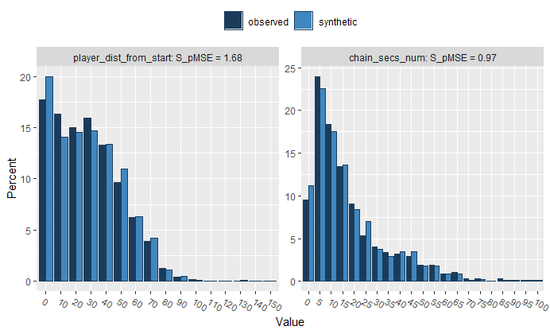

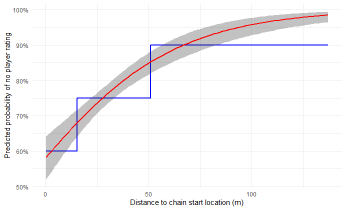

## Possession

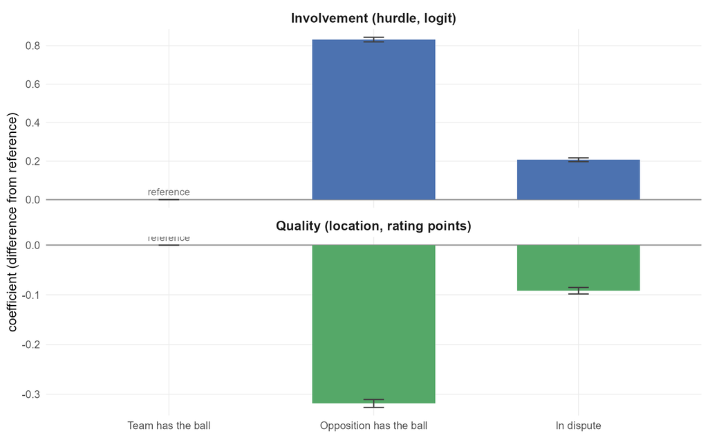

## Area x Role

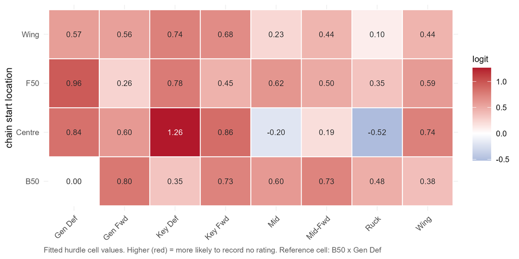

## Tagging - Variation by Role

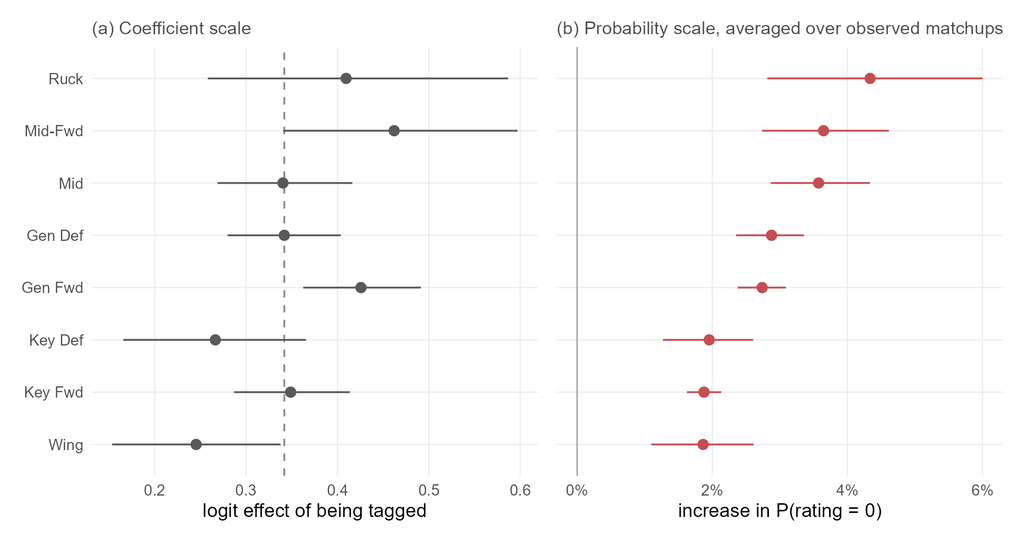

## Opponent Effects

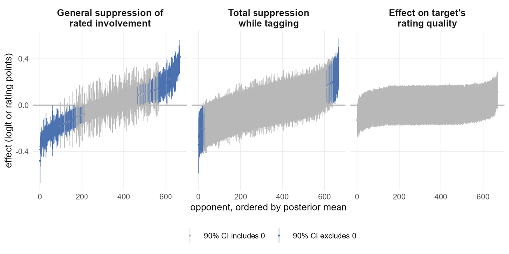

## Tagging Example

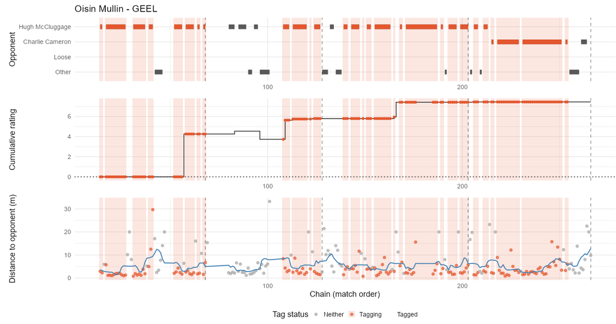